# Practical Data Science: Analyzing Stock Market Data with R

*Insight from Multiple Moving Averages*

In this lecture we’ll look at: * Looking at multiple moving averages, the 10, 50 & 200 MAs * Detrending market action

Let’s get some data:

```r
library(quantmod)
getSymbols(c('EWP', 'SPY'), src='google')
```

Let’s chart the data using a 50 and 200-period moving average. These are common periods often used as benchmarks to indicate a strengthening or weakening stock.

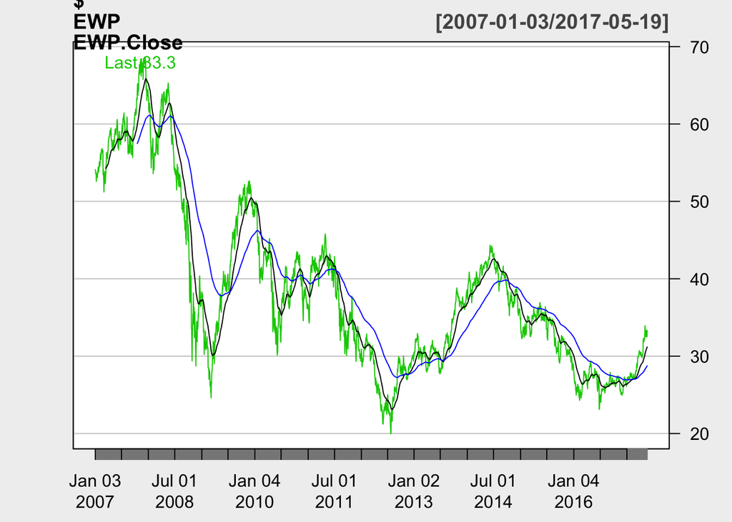

```r
chartSeries(EWP$EWP.Close, theme="white", TA="addEMA(50, col='black');addEMA(200, col='blue')")
```

Having two moving averages of different periods removes a lot of the noise. When the fast moving average is above the slow one, the market is moving upwards, and when the fast is below the slow, it is going down. Some traders will look at the crossing of these moving averages to take a directional position.

**Detrending the Data by Subtracting Two Moving Averages**

Let’s derive a new indicator by subtracting both moving averages. We’ll look at **SPY** and **EWP** as they represent different types of market, a trending and a trading one.

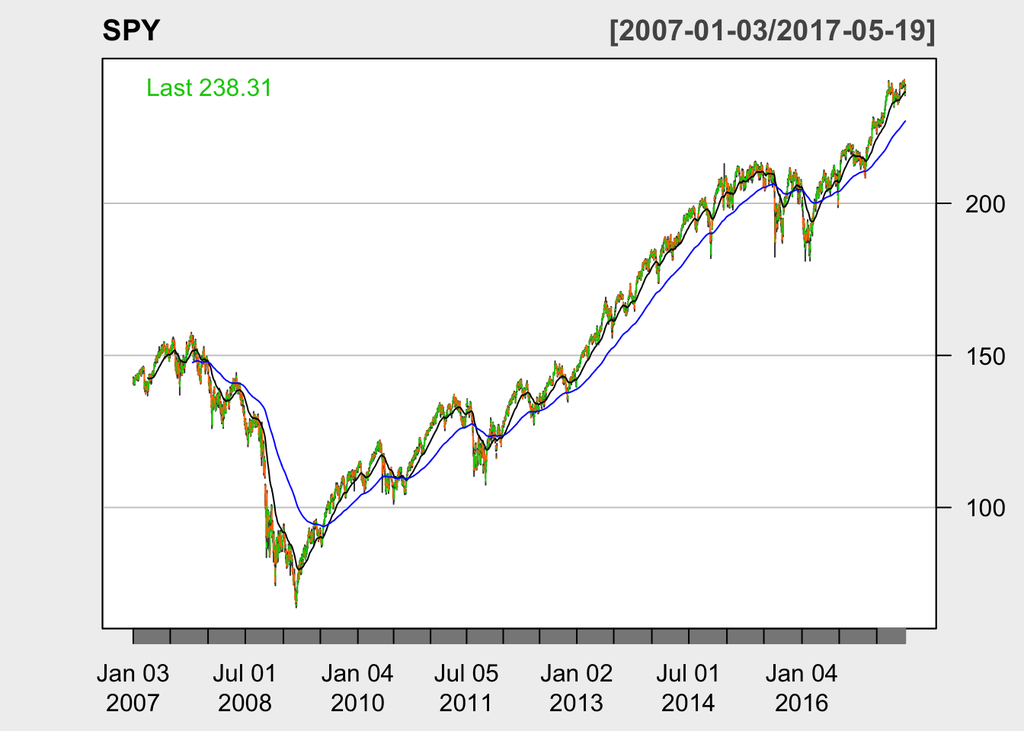

```r
chartSeries(SPY, theme="white", TA="addEMA(50, col='black');addEMA(200, col='blue')")
```

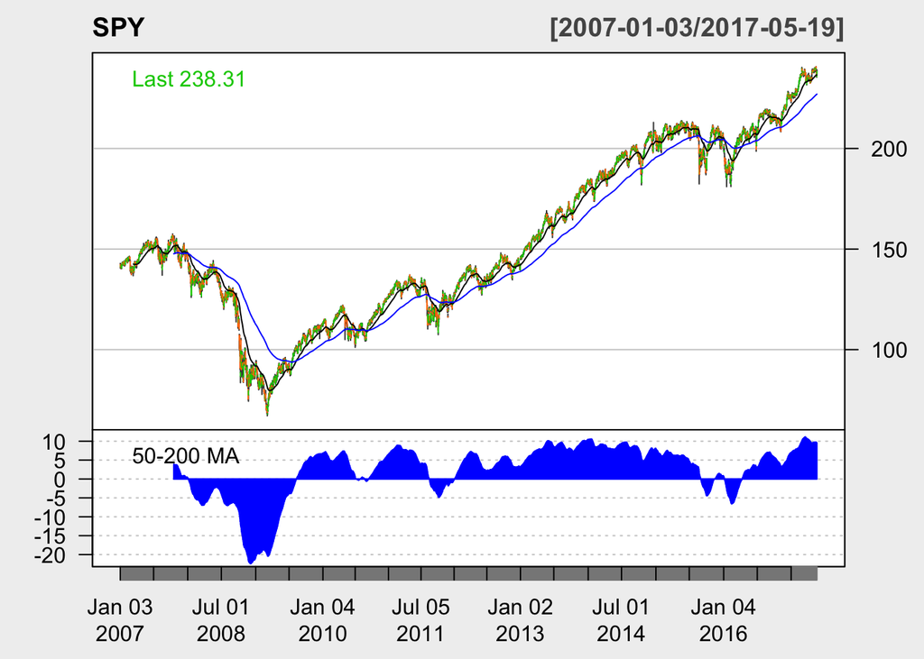

```r
SPY.EMA.50<- EMA(SPY$SPY.Close, n=50, )
SPY.EMA.200<- EMA(SPY$SPY.Close, n=200, )
addTA(SPY.EMA.50 - SPY.EMA.200,col='blue', type='h',legend="50-200 MA")
```

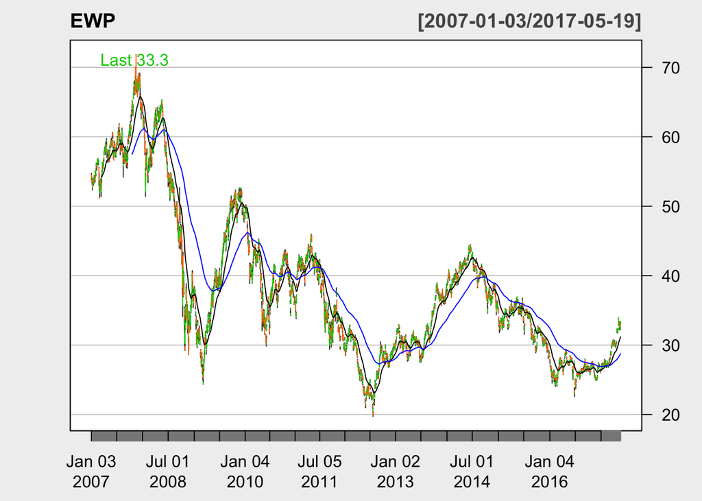

```r
library(TTR)
chartSeries(EWP, theme="white", TA="addEMA(50, col='black');addEMA(200, col='blue')")
```

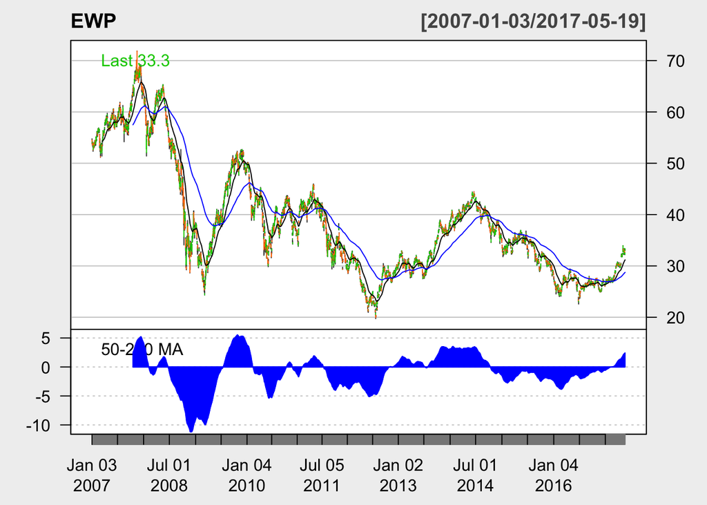

```r
EWP.EMA.50 <- EMA(EWP$EWP.Close, n=50, )
EWP.EMA.200 <- EMA(EWP$EWP.Close, n=200, )
addTA(EWP.EMA.50 - EWP.EMA.200, col='blue', type='h',legend="50-200 MA")
```

By subtracting these two moving averages together and displaying it as an indicator, we’ve removed a lot of the noise out of the short-term gyrations of the market into something easy to read. The two markets are very different and result in different patterns.

**Multiple moving averages**

So, let’s look at a simple trend following system. We’ll need 3 moving averages, a slow one for the overall trend, a fast one for the entries and exits, and a medium one to difference/de-trend the fast and slow ones.

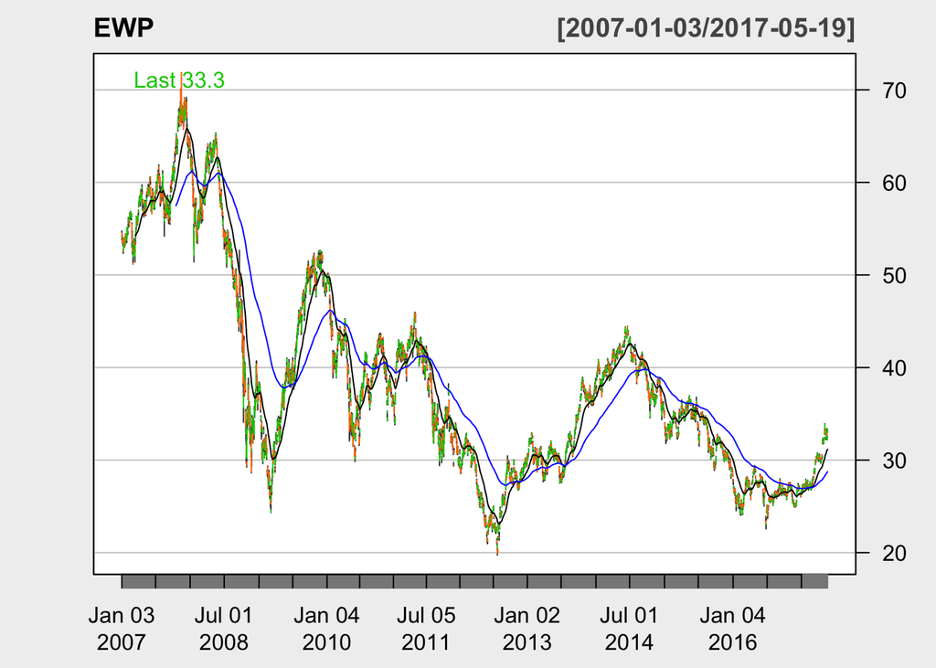

```r
chartSeries(EWP, theme="white", TA="addEMA(50, col='black');addEMA(200, col='blue')")
```

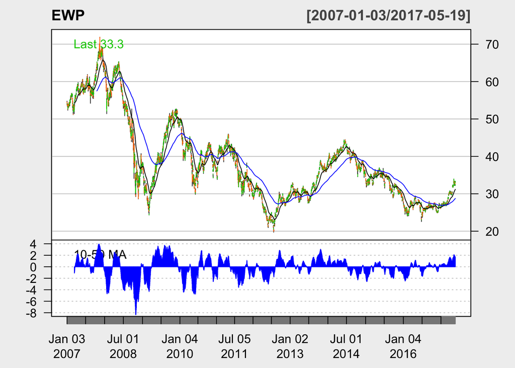

```r
EWP.EMA.10 <- EMA(EWP$EWP.Close, n=10, )
EWP.EMA.50 <- EMA(EWP$EWP.Close, n=50, )
EWP.EMA.200 <- EMA(EWP$EWP.Close, n=200, )
Fast.Diff <- EWP.EMA.10 - EWP.EMA.50
Slow.Diff <- EWP.EMA.50 - EWP.EMA.200
addTA(Fast.Diff, col='blue', type='h',legend="10-50 MA")
```

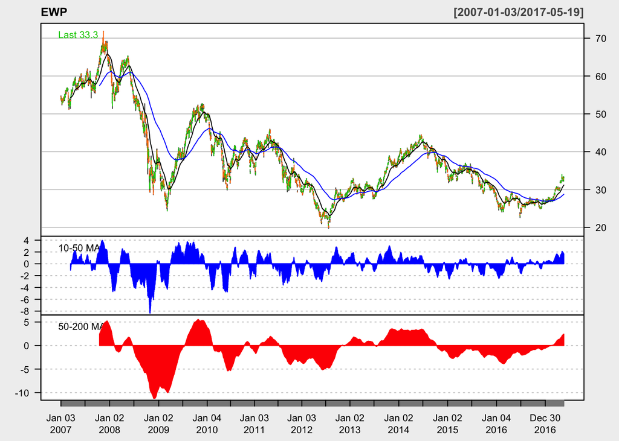

```r
addTA(Slow.Diff, col='red', type='h',legend="50-200 MA")
```

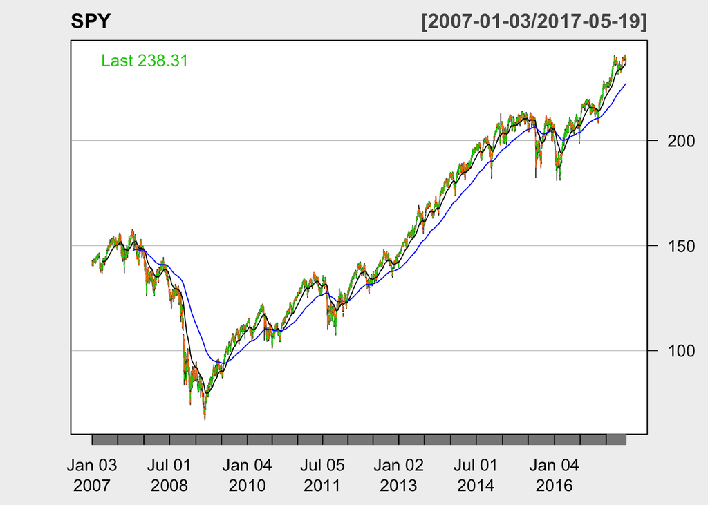

```r
chartSeries(SPY, theme="white", TA="addEMA(50, col='black');addEMA(200, col='blue')")
```

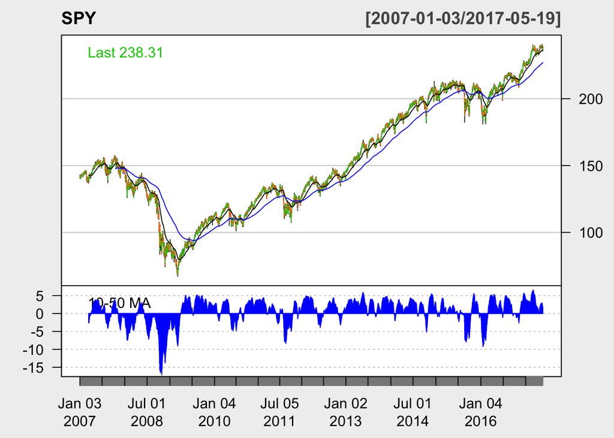

```r
SPY.EMA.10 <- EMA(SPY$SPY.Close, n=10, )
SPY.EMA.50 <- EMA(SPY$SPY.Close, n=50, )
SPY.EMA.200 <- EMA(SPY$SPY.Close, n=200, )
Fast.Diff <- SPY.EMA.10 - SPY.EMA.50
Slow.Diff <- SPY.EMA.50 - SPY.EMA.200
addTA(Fast.Diff, col='blue', type='h',legend="10-50 MA")
```

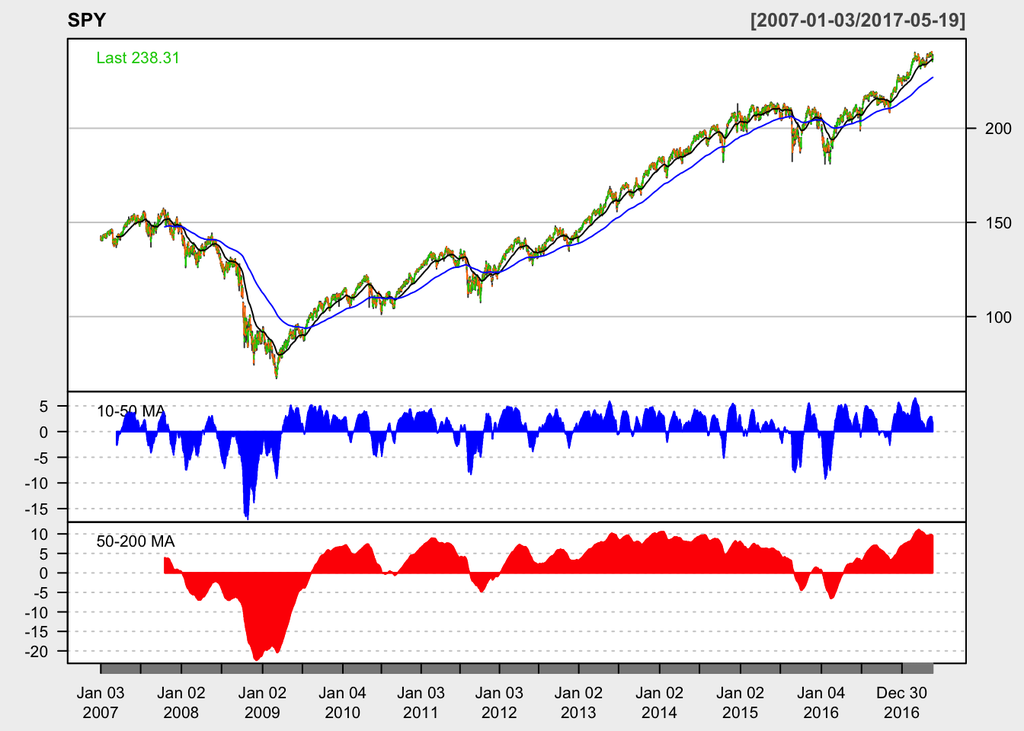

```r
addTA(Slow.Diff, col='red', type='h',legend="50-200 MA")
```

**Trading With The Trend**

You can only enter in the direction of the red Slow.Diff indicator, if its above zero you can take long signals, if its below zero, you can take short signals. The Fast.Diff indicator dictates the entries. When the blue line goes from negative to positive, its a long trade (and the slower red Slow.Diff indicator is above zero). Same thing for shorts. This is also referred to as a moving average crossover trading system.

To run this system, we need to build rules to hunt them down.

The rules are:

```
    if no position: red > 0 and blue-1 < 0 and blue > 0 go long
    if long: blue < 0 exit long

    if no position: red < 0 and blue-1 > 0 and blue < 0 go short
    if short: blue > 0 exit short
```

This is the base of a trend following system with plenty of room for improvement.

There are different ways to code this, but a simple way is to use a lag on the fast indicator.

Another key aspect in the hunt for trades is the `shift` function from the `binhf` package (https://cran.r-project.org/web/packages/binhf/index.html). This function will allow us to easily compare a vector of data with the value preceding it (or x values preceding it). Here we’ll use the shift function to find when our differenced indicators change from below to above the zero line, or from above to below (basically when the value changes sign).

Here is an example in action:

```r
# install.packages('binhf')
library(binhf)
tail(as.numeric(Fast.Diff))
tail(shift(v=as.numeric(Fast.Diff), places=1, dir="right"))
```

[output not shown]

This allows us to compare the values of two different rows on the same row. We still have our indicator value of today, but we now can compare it with yesterday’s value on the same row. Sure, we could have just easily created a loop and run through each value but by doing it this way we stick to vector comparison in its simplest form.

Now, let’s translate our trend trading system pseudo code into R code:

```r
# look for long entries
Long_Trades <- ifelse(
Slow.Diff  > 0 &
Fast.Diff  > 0 &
shift(v=as.numeric(Fast.Diff), places=1, dir="right") < 0, EWP$EWP.Close, NA)

# look for long exits (same thing but inverse signts)
Short_Trades <- ifelse(
Slow.Diff  < 0 &
Fast.Diff  < 0 &
shift(v=as.numeric(Fast.Diff), places=1, dir="right") > 0, EWP$EWP.Close, NA)
```

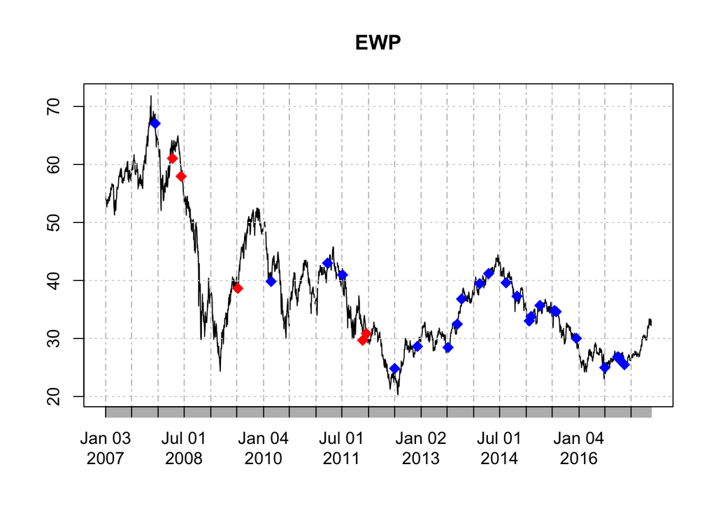

```r
plot(EWP)
points(Long_Trades, col='blue', cex=1.5, pch=18)
points(Short_Trades, col='red', cex=1.5, pch=18)
```

Mixture of entry points and that is usually how it works on a trading, bouncing trend. Though we aren’t going to design full trending systems here, a stop-loss exit order is key to any directional trading so you don’t lose everything! Let’s see what it does on trending market:

```r
EMA.Fast <- EMA(SPY$SPY.Close, n=10, )
EMA.Medium <- EMA(SPY$SPY.Close, n=50, )
EMA.Slow <- EMA(SPY$SPY.Close, n=200, )
Fast.Diff <- EMA.Fast - EMA.Medium
Slow.Diff <- EMA.Medium - EMA.Slow

# look for long entries
Long_Trades <- ifelse(
Slow.Diff  > 0 &
Fast.Diff  > 0 &
shift(v=as.numeric(Fast.Diff), places=1, dir="right") < 0, SPY$SPY.Close, NA)

# look for long exits (same thing but inverse signts)
Short_Trades <- ifelse(
Slow.Diff  < 0 &
Fast.Diff  < 0 &
shift(v=as.numeric(Fast.Diff), places=1, dir="right") > 0, SPY$SPY.Close, NA)
```

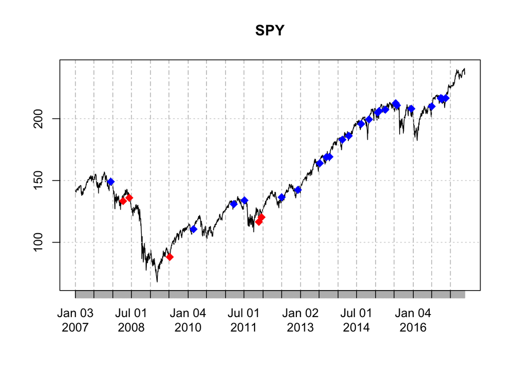

```r
plot(SPY)
points(Long_Trades, col='blue', cex=1.5, pch=18)
points(Short_Trades, col='red', cex=1.5, pch=18)
```